# Tutorial 10.2: Logistic regression on the sore throat dataset

Dataset sore contains results of a study on throat age upon surgery with general anaesthesia.  
The variable sore encodes whether a patient experienced a sore throat on waking (0: no, 1: yes) as a function of the duration of the surgery (duration) in minutes and the type of device (variable type) used to secure the airway: laryngeal mask (“mask”) or tracheal tube (“tube”) (Data taken from Agresti 2002).

- Explore the dataset
- Fit a logit model using “type” and interpret the parameter estimate
- Fit a logit model considering all predictors, interpret parameter estimates, and conduct inference about the effects.

# 1

```r
library(MASS)
library(boot)
library(car)
library(tidyverse)
sore <- read_csv("https://raw.githubusercontent.com/GTPB/PSLS20/master/data/sore.csv")
head(sore)
```

```
## # A tibble: 6 x 3
##   duration type   sore
##      <dbl> <chr> <dbl>
## 1       45 mask      0
## 2       15 mask      0
## 3       40 mask      1
## 4       83 tube      1
## 5       90 tube      1
## 6       25 tube      1
```

```r
sore$type <- as.factor(sore$type)
sore$sore <- as.factor(sore$sore)
```

# 2 Data Exploration

```r
#####################
#data exploration
#####################
table(sore[,c("type","sore")])
```

```
##       sore
## type    0  1
##   mask  4 14
##   tube  9  8
```

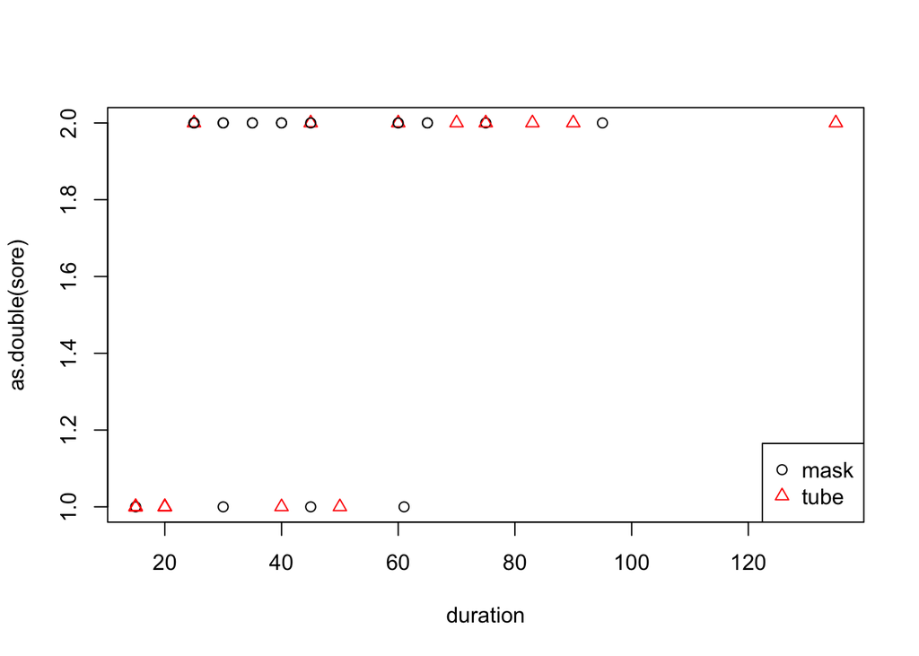

```r
plot(as.double(sore)~duration,pch=as.double(type),col=as.double(type), data=sore)
legend("bottomright",pch=1:2,col=1:2,legend=levels(sore$type))
```

# 3 Analysis

## 3.1 Fit for “type”

```r
#################
#fit a model with type
#################
fitType=glm(sore~type,data=sore,family=binomial)
#inference/interpretation
summary(fitType)
```

```
##
## Call:
## glm(formula = sore ~ type, family = binomial, data = sore)
##
## Deviance Residuals:
##    Min      1Q  Median      3Q     Max
## -1.734  -1.128   0.709   0.709   1.228
##
## Coefficients:
##             Estimate Std. Error z value Pr(>|z|)
## (Intercept)   1.2528     0.5669   2.210   0.0271 *
## typetube     -1.3705     0.7467  -1.836   0.0664 .
## ---
## Signif. codes:  0 '***' 0.001 '**' 0.01 '*' 0.05 '.' 0.1 ' ' 1
##
## (Dispersion parameter for binomial family taken to be 1)
##
##     Null deviance: 46.180  on 34  degrees of freedom
## Residual deviance: 42.578  on 33  degrees of freedom
## AIC: 46.578
##
## Number of Fisher Scoring iterations: 4
```

```r
anova(fitType,test="LRT")
```

```
## Analysis of Deviance Table
##
## Model: binomial, link: logit
##
## Response: sore
##
## Terms added sequentially (first to last)
##
##
##      Df Deviance Resid. Df Resid. Dev Pr(>Chi)
## NULL                    34     46.180
## type  1   3.6022        33     42.578   0.0577 .
## ---
## Signif. codes:  0 '***' 0.001 '**' 0.01 '*' 0.05 '.' 0.1 ' ' 1
```

```r
#############
#Interpret
#############
#odds on sore throat when wearing mask
14/4 #
```

```
## [1] 3.5
```

```r
exp(fitType$coef[1])
```

```
## (Intercept)
##         3.5
```

```r
#odds on sore throat when having tube
8/9
```

```
## [1] 0.8888889
```

```r
exp(fitType$coef[1]+fitType$coef[2])
```

```
## (Intercept)
##   0.8888889
```

```r
#odds ration type
exp(fitType$coef[2])
```

```
##  typetube
## 0.2539683
```

```r
confint(fitType)
```

```
##                  2.5 %     97.5 %
## (Intercept)  0.2275566 2.51346332
## typetube    -2.9292777 0.04379487
```

Above was not corrected for duration differences.